# Jones_Assignment5

Steve Jones

April 20, 2017

# Purpose

HomeTown Bank wants to predict whether an unknown client will subscribe to a term deposit

# Student Comment - Steve Jones

The layout of this markdown is based on a project found on Github. I’ve tweaked and altered the code to fit the requirements of Homework 5. Since this is a large Markdown - I added Echo = False to my R chunks. The actual code is available in the markdown. No need to have code in the output.

# Environment Prep - Install and load packages

##### If package not already installed then install it

Preloading all packages in this manner does not appear to work. As I got near the bottom of this markdown I had to load packages that I thought had been loaded in this section.

# Data Exploration

In this section, I load the data and explore it

```r
setwd("C:/Rockhurst/ADM/Data")

bank <- read.csv("bank-full_sjj.csv")
str(bank)
```

```
## 'data.frame':    45211 obs. of  17 variables:
##  $ age..number        : int  58 44 33 47 33 35 28 42 58 43 ...
##  $ job..category      : Factor w/ 12 levels "job_admin.","job_blue_collar",..: 5 10 3 2 12 5 5 3 6 10 ...
##  $ marital..category  : Factor w/ 3 levels "marital_divorced",..: 2 3 2 2 3 2 3 1 2 3 ...
##  $ education..category: Factor w/ 4 levels "education_primary",..: 3 2 2 4 4 3 3 3 1 2 ...
##  $ default..category  : Factor w/ 2 levels "default_no","default_yes": 1 1 1 1 1 1 1 2 1 1 ...
##  $ balance..number    : int  2143 29 2 1506 1 231 447 2 121 593 ...
##  $ housing..category  : Factor w/ 2 levels "housing_no","housing_yes": 2 2 2 2 1 2 2 2 2 2 ...
##  $ loan..category     : Factor w/ 2 levels "loan_no","loan_yes": 1 1 2 1 1 1 2 1 1 1 ...
##  $ contact..category  : Factor w/ 3 levels "contact_cellular",..: 3 3 3 3 3 3 3 3 3 3 ...
##  $ day..number        : int  5 5 5 5 5 5 5 5 5 5 ...
##  $ month..category    : Factor w/ 12 levels "month_apr","month_aug",..: 9 9 9 9 9 9 9 9 9 9 ...
##  $ duration..number   : int  261 151 76 92 198 139 217 380 50 55 ...
##  $ campaign..number   : int  1 1 1 1 1 1 1 1 1 1 ...
##  $ pdays..number      : int  -1 -1 -1 -1 -1 -1 -1 -1 -1 -1 ...
##  $ previous..number   : int  0 0 0 0 0 0 0 0 0 0 ...
##  $ poutcome..category : Factor w/ 4 levels "poutcome_failure",..: 4 4 4 4 4 4 4 4 4 4 ...
##  $ y..category        : int  0 0 0 0 0 0 0 0 0 0 ...
```

```r
names(bank)
```

```
##  [1] "age..number"         "job..category"       "marital..category"
##  [4] "education..category" "default..category"   "balance..number"
##  [7] "housing..category"   "loan..category"      "contact..category"
## [10] "day..number"         "month..category"     "duration..number"
## [13] "campaign..number"    "pdays..number"       "previous..number"
## [16] "poutcome..category"  "y..category"
```

```r
summary(bank)
```

```
##   age..number            job..category         marital..category
##  Min.   :18.00   job_blue_collar:9732   marital_divorced: 5207
##  1st Qu.:33.00   job_management :9458   marital_married :27214
##  Median :39.00   job_technician :7597   marital_single  :12790
##  Mean   :40.94   job_admin.     :5171
##  3rd Qu.:48.00   job_services   :4154
##  Max.   :95.00   job_retired    :2264
##                  (Other)        :6835
##           education..category   default..category balance..number
##  education_primary  : 6851    default_no :44396   Min.   : -8019
##  education_secondary:23202    default_yes:  815   1st Qu.:    72
##  education_tertiary :13301                        Median :   448
##  education_unknown  : 1857                        Mean   :  1362
##                                                   3rd Qu.:  1428
##                                                   Max.   :102127
##
##    housing..category  loan..category          contact..category
##  housing_no :20081   loan_no :37967   contact_cellular :29285
##  housing_yes:25130   loan_yes: 7244   contact_telephone: 2906
##                                       contact_unknown  :13020
##
##
##
##
##   day..number     month..category  duration..number campaign..number
##  Min.   : 1.00   month_may:13766   Min.   :   0.0   Min.   : 1.000
##  1st Qu.: 8.00   month_jul: 6895   1st Qu.: 103.0   1st Qu.: 1.000
##  Median :16.00   month_aug: 6247   Median : 180.0   Median : 2.000
##  Mean   :15.81   month_jun: 5341   Mean   : 258.2   Mean   : 2.764
##  3rd Qu.:21.00   month_nov: 3970   3rd Qu.: 319.0   3rd Qu.: 3.000
##  Max.   :31.00   month_apr: 2932   Max.   :4918.0   Max.   :63.000
##                  (Other)  : 6060
##  pdays..number   previous..number          poutcome..category
##  Min.   : -1.0   Min.   :  0.0000   poutcome_failure: 4901
##  1st Qu.: -1.0   1st Qu.:  0.0000   poutcome_other  : 1840
##  Median : -1.0   Median :  0.0000   poutcome_success: 1511
##  Mean   : 40.2   Mean   :  0.5803   poutcome_unknown:36959
##  3rd Qu.: -1.0   3rd Qu.:  0.0000
##  Max.   :871.0   Max.   :275.0000
##
##   y..category
##  Min.   :0.000
##  1st Qu.:0.000
##  Median :0.000
##  Mean   :0.117
##  3rd Qu.:0.000
##  Max.   :1.000
##
```

```r
# examine categorical/factor variables
# showing the number of observations with missing data (if any)
#### y
print(table(bank$y , useNA = c("always")))
```

```
##
##     0     1  <NA>
## 39922  5289     0
```

```r
#### job
print(table(bank$job , useNA = c("always")))
```

```
##
##        job_admin.   job_blue_collar  job_entrepreneur     job_housemaid
##              5171              9732              1487              1240
##    job_management       job_retired job_self_employed      job_services
##              9458              2264              1579              4154
##       job_student    job_technician    job_unemployed       job_unknown
##               938              7597              1303               288
##              <NA>
##                 0
```

```r
#### marital
print(table(bank$marital , useNA = c("always")))
```

```
##
## marital_divorced  marital_married   marital_single             <NA>
##             5207            27214            12790                0
```

```r
#### education
print(table(bank$education , useNA = c("always")))
```

```
##
##   education_primary education_secondary  education_tertiary
##                6851               23202               13301
##   education_unknown                <NA>
##                1857                   0
```

```r
#### default
print(table(bank$default , useNA = c("always")))
```

```
##
##  default_no default_yes        <NA>
##       44396         815           0
```

```r
#### housing
print(table(bank$housing , useNA = c("always")))
```

```
##
##  housing_no housing_yes        <NA>
##       20081       25130           0
```

```r
#### loan
print(table(bank$loan , useNA = c("always")))
```

```
##
##  loan_no loan_yes     <NA>
##    37967     7244        0
```

```r
#### contact
print(table(bank$contact , useNA = c("always")))
```

```
##
##  contact_cellular contact_telephone   contact_unknown              <NA>
##             29285              2906             13020                 0
```

```r
#### month
print(table(bank$month , useNA = c("always")))
```

```
##
## month_apr month_aug month_dec month_feb month_jan month_jul month_jun
##      2932      6247       214      2649      1403      6895      5341
## month_mar month_may month_nov month_oct month_sep      <NA>
##       477     13766      3970       738       579         0
```

```r
#### poutcome
print(table(bank$poutcome , useNA = c("always")))
```

```
##
## poutcome_failure   poutcome_other poutcome_success poutcome_unknown
##             4901             1840             1511            36959
##             <NA>
##                0
```

```r
#### No missing values in any of the columns


#Train = 36169
#Test = 9042


####Rearranging the columns so the target variable is first
bank<-bank[,c(17,1:16)]

#### Balance has negatives
#### Assuming that most banks have a minimum balance requirement to keep account open. I will assume Hometown min ####balance is $100

bank$balance..number <- ifelse(bank$balance..number<100, bank$balance..number * 0 + 100, bank$balance..number )


# Validation approach using 80-20 split
#set.seed(123)
#bank_train<-data.frame(bank[1:36169, ])
#bank_test<-data.frame(bank[36170:45211, ])

#### Randomized observation training and test creation
set.seed(123) #set a seed to do draws from a random uniform distribution.
bank_rand <- bank[order(runif(45211)), ]
bank_train <- bank_rand[1:36169, ] #Training data set; 20000 observations
bank_test  <-bank_rand[36170:45211, ]
```

# Data Preparation

I performed the following transformations on the data either R or directly in Excel:

- I randomly selected 80% of the observations as a model training and the remaining 20% was used for testing
- Convert Binary variable to 0 and 1 from yes and no(Excel)
- concatenate categorical variable name to all values within the column example “job_” (excel)
- Set balance to bank’s min balance requirement
- Create dummy variables for categorical variables (R)
- Data Summary Analysis (R)

## Data Preparation - Train

```
##       y..category age..number balance..number day..number duration..number
## 19296           0          58            1191           6               78
## 15829           0          30             100          21              106
## 3934            0          41             208          16              315
## 43484           1          39             603          15              214
## 9036            0          57             100           5               67
## 39632           0          21             164          26              260
##       campaign..number pdays..number previous..number job_admin.
## 19296                2             0                0          0
## 15829                3             0                0          0
## 3934                 3             0                0          0
## 43484                1             0                0          0
## 9036                 1             0                0          0
## 39632                1             0                0          0
##       job_blue_collar job_entrepreneur job_housemaid job_management
```

[output cut: 69 more lines]

## Data Preparation - Test

```r
bank_test2<-bank_test

#### y..category
### Could not get If/then/else code to work so I convert this field in Excel


#----------------------------------------------------------------------------------------------------------

#str(bank_test2)

#### age..number
#----------------------------------------------------------------------------------------------------------

####
#----------------------------------------------------------------------------------------------------------

#### job..category
library(psych)
bank_test2<- cbind(bank_test2,dummy.code(bank_test2$job..category))

#Delete original catagorical variable
bank_test2$job..category <- NULL
#----------------------------------------------------------------------------------------------------------


#head(bank_test2)

#### marital..category

bank_test2<- cbind(bank_test2,dummy.code(bank_test2$marital..category))
#Delete original catagorical variable
bank_test2$marital..category<- NULL
#head(bank_test2)
#----------------------------------------------------------------------------------------------------------


#### education..category

bank_test2<- cbind(bank_test2,dummy.code(bank_test2$education..category))
#Delete original catagorical variable
bank_test2$education..category <- NULL
#----------------------------------------------------------------------------------------------------------


#### default..category

bank_test2<- cbind(bank_test2,dummy.code(bank_test2$default..category))
#Delete original catagorical variable
bank_test2$default..category <- NULL
#----------------------------------------------------------------------------------------------------------

#### balance..number
bank_test2$balance..number <- ifelse(bank_test2$balance..number<100, bank_test2$balance..number * 0 + 100, bank_test2$balance..number )

#----------------------------------------------------------------------------------------------------------


#### housing..category

bank_test2<- cbind(bank_test2,dummy.code(bank_test2$housing..category))
#Delete original catagorical variable
bank_test2$housing..category <- NULL
#----------------------------------------------------------------------------------------------------------

#### loan..category

bank_test2<- cbind(bank_test2,dummy.code(bank_test2$loan..category))
#Delete original catagorical variable
bank_test2$loan..category <- NULL
#----------------------------------------------------------------------------------------------------------

#### contact..category

bank_test2<- cbind(bank_test2,dummy.code(bank_test2$contact..category))
#Delete original catagorical variable
bank_test2$contact..category <- NULL
#----------------------------------------------------------------------------------------------------------

#### day..number
#----------------------------------------------------------------------------------------------------------


#### month..category

bank_test2<- cbind(bank_test2,dummy.code(bank_test2$month..category))
#Delete original catagorical variable
bank_test2$month..category <- NULL
#----------------------------------------------------------------------------------------------------------


#### duration..number

#----------------------------------------------------------------------------------------------------------

#### campaign..number

#----------------------------------------------------------------------------------------------------------

#### pdays..number
bank_test2$pdays..number <- ifelse(bank_test2$pdays..number<0, 0, bank_test2$pdays..number )



#dummy variable for pdays -previous contact yes or no ; 1 or 0  when 999
bank_test2$previous_contact <- as.numeric(ifelse(bank_test2$pdays == 999, 0, 1))
#----------------------------------------------------------------------------------------------------------

#### previous..number

#----------------------------------------------------------------------------------------------------------

#### poutcome..category

bank_test2<- cbind(bank_test2,dummy.code(bank_test2$poutcome..category))
#Delete original catagorical variable
bank_test2$poutcome..category <- NULL

#----------------------------------------------------------------------------------------------------------

head(bank_test2)
```

```
##       y..category age..number balance..number day..number duration..number
## 15332           0          31             117          18               41
## 32623           0          32             329          17              237
## 10390           0          54             734          12              124
## 22155           0          42             100          21              656
## 37623           1          26            1006          14              667
## 28679           0          36             583          30              859
##       campaign..number pdays..number previous..number job_admin.
## 15332                1             0                0          0
## 32623                1             0                0          0
## 10390                1             0                0          0
## 22155                2             0                0          0
## 37623                1             0                0          0
## 28679                1           235                1          0
##       job_blue_collar job_entrepreneur job_housemaid job_management
```

[output cut: 69 more lines]

# Model Building

In this section I created my models. The following are the three different approaches that will be used here:

- Model 1: This model will be created by using logit function of Generalized Logistics Model (GLM).
- Model 2: This model will be created by using Decision tree function.
- Model 3: This model will be created by using classification technique Random Forests model.

## Decision tree - Model 2

```
## n= 36169
##
## node), split, n, loss, yval, (yprob)
##       * denotes terminal node
##
##  1) root 36169 4237 0 (0.88285548 0.11714452)
##    2) duration..number< 472.5 31402 2278 0 (0.92745685 0.07254315)
##      4) poutcome_success< 0.5 30409 1664 0 (0.94527936 0.05472064) *
##      5) poutcome_success>=0.5 993  379 1 (0.38167170 0.61832830)
##       10) duration..number< 132 189   42 0 (0.77777778 0.22222222) *
##       11) duration..number>=132 804  232 1 (0.28855721 0.71144279) *
##    3) duration..number>=472.5 4767 1959 0 (0.58904972 0.41095028)
##      6) duration..number< 800.5 3214 1063 0 (0.66925949 0.33074051)
##       12) poutcome_success< 0.5 3055  936 0 (0.69361702 0.30638298) *
##       13) poutcome_success>=0.5 159   32 1 (0.20125786 0.79874214) *
##      7) duration..number>=800.5 1553  657 1 (0.42305216 0.57694784) *
```

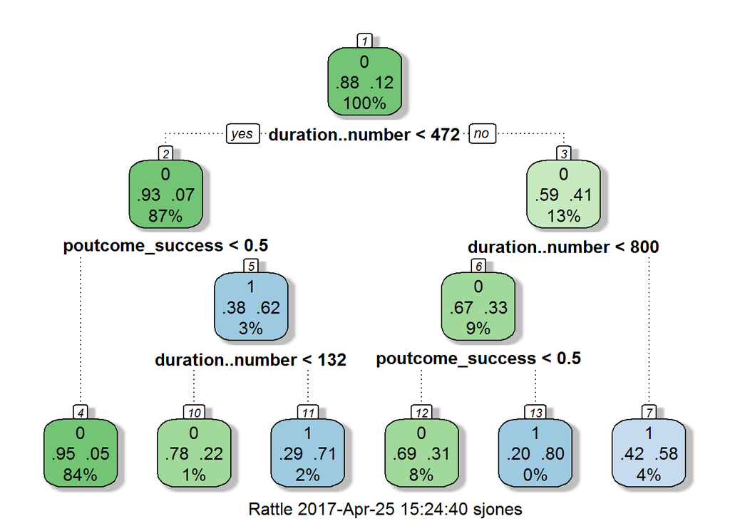

## RandomForest- Model 3

```
##
## Call:
##  randomForest(formula = as.factor(y..category) ~ ., data = bank_train2,      importance = TRUE, ntree = 50)
##                Type of random forest: classification
##                      Number of trees: 50
## No. of variables tried at each split: 7
##
##         OOB estimate of  error rate: 9.54%
## Confusion matrix:
##       0    1 class.error
## 0 30979  953  0.02984467
## 1  2499 1738  0.58980411
```

```
##                              0            1 MeanDecreaseAccuracy
## age..number         11.0091802  5.944038585           12.9138206
## balance..number      3.4258736  3.676535692            5.5687568
## day..number         14.8336705  3.402282609           15.1493101
## duration..number    44.6603990 57.598354232           59.9581798
## campaign..number     5.4914673  4.275069266            7.3877848
## pdays..number        6.4830343  6.364031136            7.8827036
## previous..number     3.3638081  3.100759400            3.7906878
## job_admin.           0.9358740 -0.418238422            0.5999903
## job_blue_collar      0.8842404  2.474119199            1.9628646
## job_entrepreneur     1.1025699  3.283605493            2.6987419
## job_housemaid        0.3432050  0.982621165            0.7945057
## job_management       1.2864178  1.289684705            1.7917421
## job_retired          1.1602105  1.319550747            1.7387356
## job_self_employed    0.3735568  0.188417045            0.3897601
## job_services         0.3803270  1.829035215            1.1848045
## job_student          5.1223611  0.006098025            5.2302789
## job_technician       2.0585049  1.009849412            2.2740009
## job_unemployed       0.1789979 -1.702259524           -0.8352502
## job_unknown          2.7429184 -0.623488143            2.3888426
## marital_divorced    -0.8813607  3.413572145            0.9611069
## marital_married      2.6470208  4.806064803            5.8696266
## marital_single       2.0709657  3.273835992            4.0364653
## education_primary    1.6998496  2.431213323            2.5087465
## education_secondary -1.1744154  3.682684389            0.5587396
## education_tertiary   1.7115220  2.165014656            2.7328834
## education_unknown    0.4061674 -1.043668621           -0.2463120
## default_no           1.1455506 -0.395174271            0.7279504
## default_yes         -0.2393821  0.133440812           -0.1619362
## housing_no           6.3584520  5.628075592            7.7993053
## housing_yes          6.5828965  5.707747521            7.0084577
## loan_no             -0.2683946  6.397647271            4.4316040
## loan_yes             2.1253906  4.005193190            4.9345794
## contact_cellular     6.7045895  6.295516723            6.9486008
## contact_telephone    3.9376336  0.731316148            4.0692760
## contact_unknown      8.4073175  3.069710229            8.6048337
## month_apr            8.8118918  7.832393897            9.9690330
## month_aug           10.2961006 -1.505308639           10.1661835
## month_dec            6.5013813  4.242517994            7.8155696
## month_feb            9.3478613  0.987535937            9.3857480
```

[output cut: 51 more lines]

```
## month_dec                  24.350986
## month_feb                  53.504249
## month_jan                  31.148976
## month_jul                  55.579659
## month_jun                  85.086618
## month_mar                  96.314423
## month_may                  59.452528
## month_nov                  50.802297
## month_oct                  76.704670
## month_sep                  57.364572
## previous_contact            0.000000
## poutcome_failure           63.850455
## poutcome_other             39.343160
## poutcome_success          377.562070
## poutcome_unknown           48.216059
```

```
##
## Call:
##  randomForest(formula = as.factor(y..category) ~ ., data = bank_train2,      importance = TRUE, ntree = 100)
##                Type of random forest: classification
##                      Number of trees: 100
## No. of variables tried at each split: 7
##
##         OOB estimate of  error rate: 9.43%
## Confusion matrix:
##       0    1 class.error
## 0 31051  881  0.02758988
## 1  2528 1709  0.59664857
```

```
##                              0           1 MeanDecreaseAccuracy
## age..number         15.0392147  7.53722838          17.53861717
## balance..number      1.4510741  3.62271179           3.61534774
## day..number         25.0458592  4.16682197          26.09892858
## duration..number    55.2047702 90.52701019          82.14345714
## campaign..number     7.4544985  5.18076085           8.75554790
## pdays..number       12.2246040 12.34104644          14.15031521
## previous..number     5.2528536  4.66914467           5.99803869
## job_admin.           1.7653460  1.42563844           2.32363941
## job_blue_collar      1.3545670  5.12556413           4.26428428
## job_entrepreneur    -0.8300636  2.96607601           1.12077542
## job_housemaid        2.1591752 -0.61395890           1.21675970
## job_management       0.7945074 -0.33967296           0.48817893
## job_retired          1.2279795  1.71489184           2.64412711
## job_self_employed   -0.8146180 -1.32742109          -1.35515951
## job_services         0.1030927 -0.04628274           0.06526188
## job_student          6.0362132  0.92526698           6.55734888
## job_technician       0.3914604  0.33635133           0.48759284
## job_unemployed      -0.9573596 -2.27824938          -1.94559532
## job_unknown          2.4190281  1.03937151           2.66828529
## marital_divorced     1.9342604  3.05009685           3.83851171
## marital_married      5.0046487  4.11086169           6.87922556
## marital_single       2.9224943  3.14240984           5.26238451
## education_primary    5.0336405  4.03311706           6.47270105
## education_secondary  3.5072623  1.37745188           3.98037045
## education_tertiary   3.5944289  3.73890749           5.13934272
## education_unknown    2.7237054 -0.13540456           2.45206790
## default_no          -0.1466213 -1.14199065          -0.74555752
## default_yes          1.2124163  1.16031681           1.72563841
## housing_no          10.7348799  8.37800392          11.59647375
## housing_yes          7.8332762  8.30746162           9.33339089
## loan_no              0.1307584  6.78284669           4.55261931
## loan_yes            -0.3148208  6.46197142           5.19418665
## contact_cellular     9.3695433  7.37733268           9.98133217
## contact_telephone    5.0519975  1.71465719           5.33289817
## contact_unknown     12.8947025  5.47365927          13.60535337
## month_apr           12.4854843 10.16920334          14.36308484
## month_aug           14.2523269 -2.07493907          14.49280652
## month_dec            9.3336839  3.94727624          10.22405325
## month_feb           14.9766653  3.59631610          15.21589158
```

[output cut: 51 more lines]

```
## month_dec                  22.756046
## month_feb                  56.636440
## month_jan                  31.593380
## month_jul                  56.693923
## month_jun                  78.115350
## month_mar                 100.049388
## month_may                  61.560778
## month_nov                  53.363644
## month_oct                  73.902625
## month_sep                  56.240363
## previous_contact            0.000000
## poutcome_failure           55.695018
## poutcome_other             28.913967
## poutcome_success          356.722717
## poutcome_unknown           56.478001
```

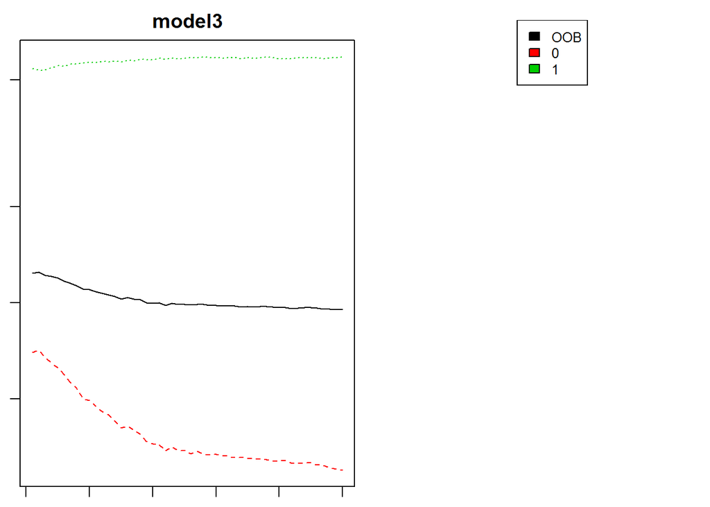

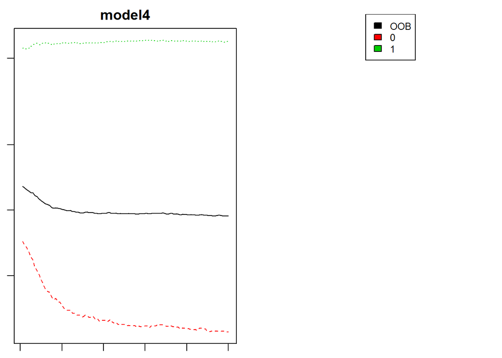

# Final Recommendation

My models indicated that the variable “duration” is the most important variable by far. The duration variable has positive impact in subscription outcome. It could be due to the fact that longer the customer stays on phone, a more productive conversation is taking place to get the customer start their term deposit Account.

# References

[Layout and Structure of this Markdown](https://github.com/kishkp/data621-ctg5/blob/master/Final%20Project/apa8.Rmd)

[How to create a Table of Content in R Markdown](http://stackoverflow.com/questions/23957278/how-to-add-table-of-contents-in-rmarkdown)